# Project3

```python
import pandas as pd
import matplotlib.pyplot as plt
import seaborn as sns
import statsmodels.formula.api
import numpy as np
from sklearn.linear_model import LinearRegression

# Read in the content
data = pd.read_csv("https://raw.githubusercontent.com/jennybc/gapminder/main/data-raw/08_gap-every-five-years.tsv", sep= '\t')
data.head()
```

|  | country | continent | year | lifeExp | pop | gdpPercap |
| --- | --- | --- | --- | --- | --- | --- |
| 0 | Afghanistan | Asia | 1952 | 28.801 | 8425333 | 779.445314 |
| 1 | Afghanistan | Asia | 1957 | 30.332 | 9240934 | 820.853030 |
| 2 | Afghanistan | Asia | 1962 | 31.997 | 10267083 | 853.100710 |
| 3 | Afghanistan | Asia | 1967 | 34.020 | 11537966 | 836.197138 |
| 4 | Afghanistan | Asia | 1972 | 36.088 | 13079460 | 739.981106 |

**EXERCISE 1**

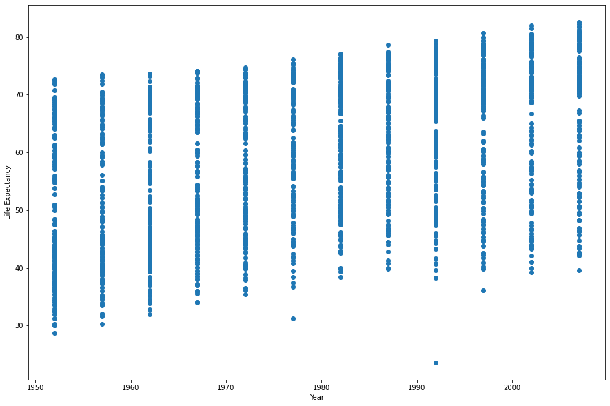

```python
plt.figure(figsize = (15,10))
plt.scatter(data['year'], data['lifeExp'])
plt.xlabel("Year")
plt.ylabel("Life Expectancy")
```

**QUESTION 1**

The general trend displays that life expectancy increases as time goes on, and seems to increase linearly.

**QUESTION 2**

Towards the beginning, the distribution is skewed towards the bottom, with a larger distribution on the lower end. Around the middle, the graph has a more symmetric distirbution. At the end, the graph is skewed towards having a higher distribution at the top (higher life expectancy). It is not unimodal.

**QUESTION 3**

I would expect to reject the null hypothesis, since there is an observable ttrend wthin the data that was stated in question 1.

**QUESTION 4**

The violin plot would resemble the plot from before. With somewhat linearly increasing plots.

**QUESTION 5**

I would assume the violin plot of residuals to have a high density in the negative region at the beginning and then a high density in the positive region at the end. This is because in the first half, there is a high densty of values below the regression line, and the opposite towards more recent dates.

**EXERCISE 2**

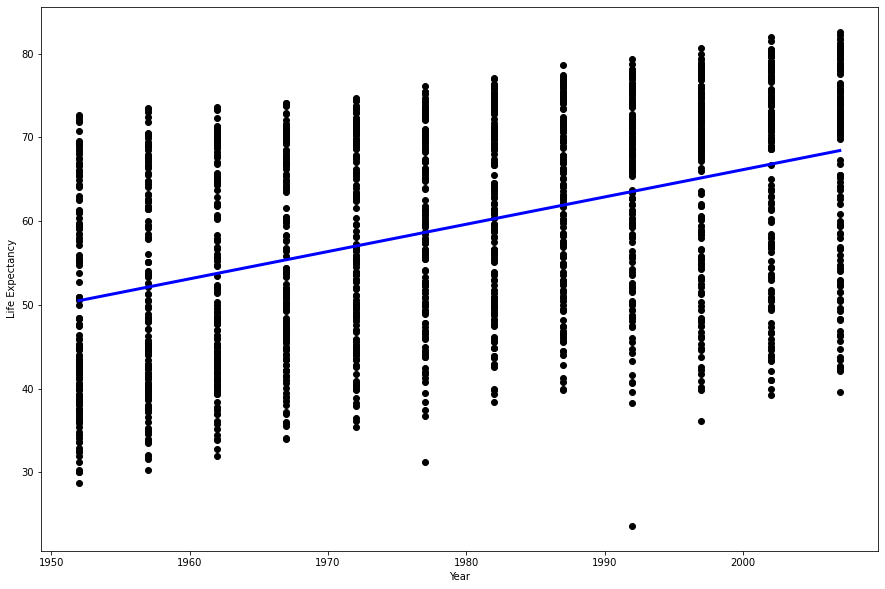

```python
# Generate the scatterplot
x = np.array(data['year']).reshape(-1,1)
y = np.array(data['lifeExp'])
reg = LinearRegression().fit(x,y)
plt.figure(figsize = (15,10))
plt.scatter(data['year'], data['lifeExp'], color="black")

# Generate the linear regression
ypred = reg.predict(x)
plt.plot(x, ypred, color="blue", linewidth=3)
plt.xlabel("Year")
plt.ylabel("Life Expectancy")
```

```python
results = statsmodels.formula.api.ols(formula="y ~ x ", data=data).fit()
results.summary()
```

OLS Regression Results

| Dep. Variable: | y | R-squared: | 0.190 |
| --- | --- | --- | --- |
| Model: | OLS | Adj. R-squared: | 0.189 |
| Method: | Least Squares | F-statistic: | 398.6 |
| Date: | Tue, 16 Nov 2021 | Prob (F-statistic): | 7.55e-80 |
| Time: | 21:41:07 | Log-Likelihood: | -6597.9 |
| No. Observations: | 1704 | AIC: | 1.320e+04 |
| Df Residuals: | 1702 | BIC: | 1.321e+04 |
| Df Model: | 1 |  |  |
| Covariance Type: | nonrobust |  |  |

|  | coef | std err | t | P>\|t\| | [0.025 | 0.975] |
| --- | --- | --- | --- | --- | --- | --- |
| Intercept | -585.6522 | 32.314 | -18.124 | 0.000 | -649.031 | -522.273 |
| x | 0.3259 | 0.016 | 19.965 | 0.000 | 0.294 | 0.358 |

| Omnibus: | 386.124 | Durbin-Watson: | 0.197 |
| --- | --- | --- | --- |
| Prob(Omnibus): | 0.000 | Jarque-Bera (JB): | 90.750 |
| Skew: | -0.268 | Prob(JB): | 1.97e-20 |
| Kurtosis: | 2.004 | Cond. No. | 2.27e+05 |

Warnings:  
[1] Standard Errors assume that the covariance matrix of the errors is correctly specified.  
[2] The condition number is large, 2.27e+05. This might indicate that there are  
strong multicollinearity or other numerical problems.

**QUESTION 6**

On average, life expectancy increases by .3259 years each year around the world.

**QUESTION 7**

You can reject the null because the p value is 0 which is < .05. This means there is a significant relationship between the data points

**EXERCISE 3**

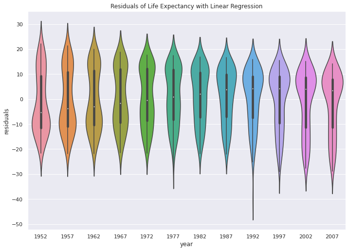

```python
data['residuals'] = data['lifeExp'] - ypred
sns.set(rc={'figure.figsize':(11.7,8.27)})
sns.violinplot(x = data['year'] , y=data['residuals']).set_title('Residuals of Life Expectancy with Linear Regression')
```

**QUESTION 8**

It somewhat matches my expectations with more density at the bottom of the beginning ones and higher density at the top of more recent years. However, there is a somewhat linear decline (at least with the top values of residuals) as time goes along that I did not predict.

**EXERCISE 4**

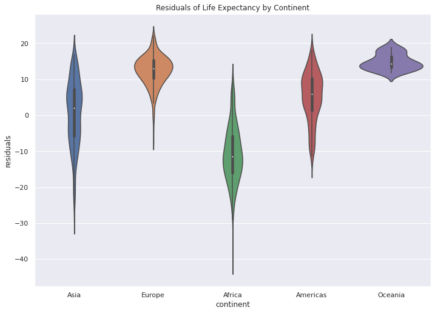

```python
sns.set(rc={'figure.figsize':(11.7,8.27)})
sns.violinplot(x = data['continent'] , y=data['residuals']).set_title('Residuals of Life Expectancy by Continent')
```

**QUESTION 9**

There does seem to be a dependence. For example, Oceania and Europe almost exclusively has a dense area of positive residuals. The Americas seem to be more spread out with a slight skew towards low positive residuals, and Africa has more denssity of negatuve residuals. This would suggest that when doing the other regressions, it is less accurate when used in a specific continent due to the dependence on that. The regresion analysis is combining all continents, which each have their own distinct life expectancy ( it is not consistant between continents).

**EXERCISE 5**

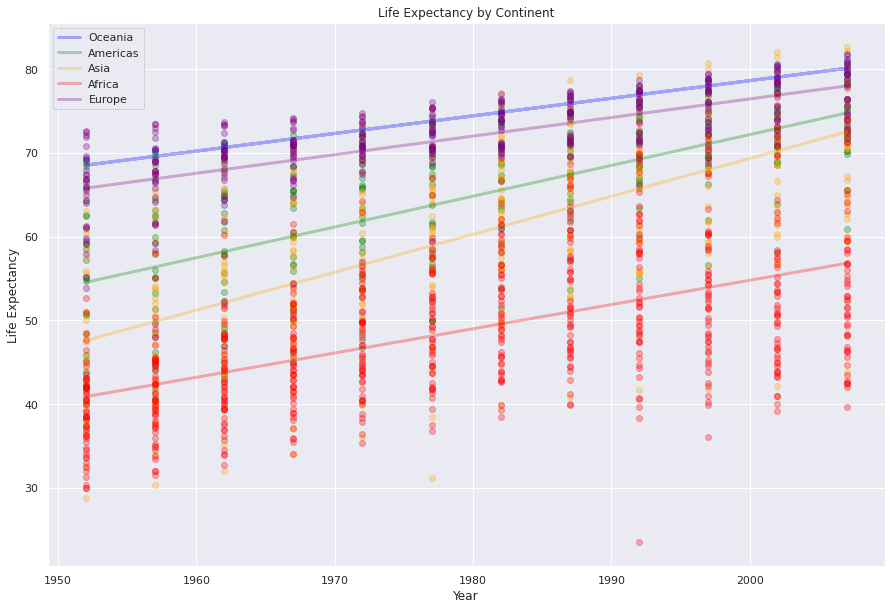

```python
# Plot each continent by taking a portion of the dataframe
oceania = data[data['continent'] == 'Oceania']
x = np.array(oceania['year']).reshape(-1,1)
y = np.array(oceania['lifeExp'])
reg = LinearRegression().fit(x,y)
plt.figure(figsize = (15,10))
plt.scatter(oceania['year'], oceania['lifeExp'], color="blue", alpha = .3)
ypred = reg.predict(x)
plt.plot(x, ypred, color="blue", linewidth=3, alpha = .3)

americas = data[data['continent'] == 'Americas']
x = np.array(americas['year']).reshape(-1,1)
y = np.array(americas['lifeExp'])
reg = LinearRegression().fit(x,y)
plt.scatter(americas['year'], americas['lifeExp'], color="green", alpha = .3)
ypred = reg.predict(x)
plt.plot(x, ypred, color="green", linewidth=3, alpha = .3)

asia = data[data['continent'] == 'Asia']
x = np.array(asia['year']).reshape(-1,1)
y = np.array(asia['lifeExp'])
reg = LinearRegression().fit(x,y)
plt.scatter(asia['year'], asia['lifeExp'], color="orange", alpha = .3)
ypred = reg.predict(x)
plt.plot(x, ypred, color="orange", linewidth=3, alpha = .3)

africa = data[data['continent'] == 'Africa']
x = np.array(africa['year']).reshape(-1,1)
y = np.array(africa['lifeExp'])
reg = LinearRegression().fit(x,y)
plt.scatter(africa['year'], africa['lifeExp'], color="red", alpha = .3)
ypred = reg.predict(x)
plt.plot(x, ypred, color="red", linewidth=3, alpha = .3)

europe = data[data['continent'] == 'Europe']
x = np.array(europe['year']).reshape(-1,1)
y = np.array(europe['lifeExp'])
reg = LinearRegression().fit(x,y)
plt.scatter(europe['year'], europe['lifeExp'], color="purple", alpha = .3)
ypred = reg.predict(x)
plt.plot(x, ypred, color="purple", linewidth=3, alpha = .3)




# Set up graph features
plt.xlabel("Year")
plt.ylabel("Life Expectancy")
plt.legend(['Oceania' , 'Americas', 'Asia', 'Africa', 'Europe'])
plt.title("Life Expectancy by Continent")
```

**QUESTION 10**

Yes. It is clear that there is a wide variation of life expectancy between continents, by the variation in both the intercepts and slope of the data points. In order to more accurately predict expectancy from any specific continent, it would be advantageous to specify what continent you intend to look at, in addition to the year.

**EXERCISE 6**

```python
regression = statsmodels.formula.api.ols(formula = 'lifeExp ~ year * continent', data = data).fit()
print(regression.summary())
```

```
                            OLS Regression Results
==============================================================================
Dep. Variable:                lifeExp   R-squared:                       0.693
Model:                            OLS   Adj. R-squared:                  0.691
Method:                 Least Squares   F-statistic:                     424.3
Date:                Tue, 16 Nov 2021   Prob (F-statistic):               0.00
Time:                        21:41:09   Log-Likelihood:                -5771.9
No. Observations:                1704   AIC:                         1.156e+04
Df Residuals:                    1694   BIC:                         1.162e+04
Df Model:                           9
Covariance Type:            nonrobust
==============================================================================================
                                 coef    std err          t      P>|t|      [0.025      0.975]
----------------------------------------------------------------------------------------------
Intercept                   -524.2578     32.963    -15.904      0.000    -588.911    -459.605
continent[T.Americas]       -138.8484     57.851     -2.400      0.016    -252.315     -25.382
continent[T.Asia]           -312.6330     52.904     -5.909      0.000    -416.396    -208.870
continent[T.Europe]          156.8469     54.498      2.878      0.004      49.957     263.737
continent[T.Oceania]         182.3499    171.283      1.065      0.287    -153.599     518.298
year                           0.2895      0.017     17.387      0.000       0.257       0.322
year:continent[T.Americas]     0.0781      0.029      2.673      0.008       0.021       0.135
year:continent[T.Asia]         0.1636      0.027      6.121      0.000       0.111       0.216
year:continent[T.Europe]      -0.0676      0.028     -2.455      0.014      -0.122      -0.014
year:continent[T.Oceania]     -0.0793      0.087     -0.916      0.360      -0.249       0.090
==============================================================================
Omnibus:                       27.121   Durbin-Watson:                   0.242
Prob(Omnibus):                  0.000   Jarque-Bera (JB):               44.106
Skew:                          -0.121   Prob(JB):                     2.65e-10
Kurtosis:                       3.750   Cond. No.                     2.09e+06
==============================================================================

Warnings:
[1] Standard Errors assume that the covariance matrix of the errors is correctly specified.
[2] The condition number is large, 2.09e+06. This might indicate that there are
strong multicollinearity or other numerical problems.
```

```python
regression.params
```

```
Intercept                    -524.257846
continent[T.Americas]        -138.848447
continent[T.Asia]            -312.633049
continent[T.Europe]           156.846852
continent[T.Oceania]          182.349883
year                            0.289529
year:continent[T.Americas]      0.078122
year:continent[T.Asia]          0.163593
year:continent[T.Europe]       -0.067597
year:continent[T.Oceania]      -0.079257
dtype: float64
```

**QUESTION 11**

**QUESTION 12**

Each corresponds to a specific continent as stated. The general variable year corresponds to the expectancy in Africa

```python
regression.params[5:10]
```

```
year                          0.289529
year:continent[T.Americas]    0.078122
year:continent[T.Asia]        0.163593
year:continent[T.Europe]     -0.067597
year:continent[T.Oceania]    -0.079257
dtype: float64
```

**EXERCISE 7**

Perform an F-test that compares how well two models fit your data: (a) the linear regression models from Exercise 2 (only including year as a covariate) and (b) Exercise 6 (including interaction between year and continent). The F-test is obtained by calling fvalue from the results of exercises 2 and 6.

```python
print("Exercise 2: ", results.fvalue)
print("p value Exercise 2: ", results.f_pvalue)

print("Exercise 6:", regression.fvalue)
print("p value Exercise 6:", regression.f_pvalue)
```

```
Exercise 2:  398.6047457117622
p value Exercise 2:  7.546794625598736e-80
Exercise 6: 424.2729023400693
p value Exercise 6: 0.0
```

**QUESTION 13**

**EXERCISE 8**

```
[47.60403713 49.86964914 52.13526116 ... 53.93209223 55.37973855
 56.82738486]
```

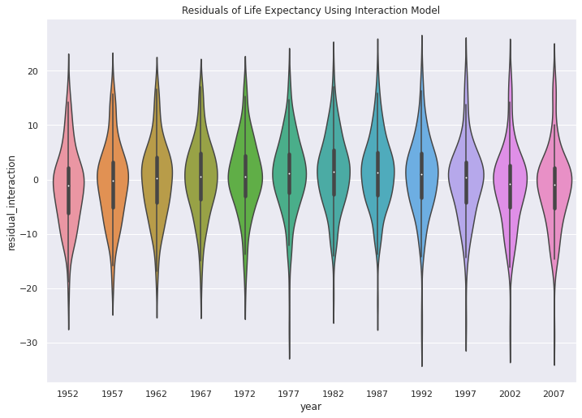

```python
prediction = regression.predict()
print(prediction)
data['continent_interaction'] = pd.Series(prediction)
data['residual_interaction']= data['lifeExp'] - data['continent_interaction']

sns.set(rc={'figure.figsize':(11.7,8.27)})
sns.violinplot(x = data['year'] , y=data['residual_interaction']).set_title('Residuals of Life Expectancy Using Interaction Model')
```